# Data Visualization

# Data Visualization : Bivariate

**Bivariate plots:**

- **`Scatter plots` for quantitative variable vs quantitaive variable**
- **`Violin plots` for quantitative variable vs qualitative variable**
- **`Clustered bar charts` for qualitative variable vs qualitative variable**

## Scatter plots : plt.scatter( ) , sns.regplot( )

```python
import pandas as pd
import numpy as np
import matplotlib.pyplot as plt
import seaborn as sns

%matplotlib inline
df = pd.read_csv('fuel_econ.csv')
df.head()
```

|  | id | make | model | year | VClass | drive | trans | fuelType | cylinders | displ | pv2 | pv4 | city | UCity | highway | UHighway | comb | co2 | feScore | ghgScore |
| --- | --- | --- | --- | --- | --- | --- | --- | --- | --- | --- | --- | --- | --- | --- | --- | --- | --- | --- | --- | --- |
| 0 | 32204 | Nissan | GT-R | 2013 | Subcompact Cars | All-Wheel Drive | Automatic (AM6) | Premium Gasoline | 6 | 3.8 | 79 | 0 | 16.4596 | 20.2988 | 22.5568 | 30.1798 | 18.7389 | 471 | 4 | 4 |
| 1 | 32205 | Volkswagen | CC | 2013 | Compact Cars | Front-Wheel Drive | Automatic (AM-S6) | Premium Gasoline | 4 | 2.0 | 94 | 0 | 21.8706 | 26.9770 | 31.0367 | 42.4936 | 25.2227 | 349 | 6 | 6 |
| 2 | 32206 | Volkswagen | CC | 2013 | Compact Cars | Front-Wheel Drive | Automatic (S6) | Premium Gasoline | 6 | 3.6 | 94 | 0 | 17.4935 | 21.2000 | 26.5716 | 35.1000 | 20.6716 | 429 | 5 | 5 |
| 3 | 32207 | Volkswagen | CC 4motion | 2013 | Compact Cars | All-Wheel Drive | Automatic (S6) | Premium Gasoline | 6 | 3.6 | 94 | 0 | 16.9415 | 20.5000 | 25.2190 | 33.5000 | 19.8774 | 446 | 5 | 5 |
| 4 | 32208 | Chevrolet | Malibu eAssist | 2013 | Midsize Cars | Front-Wheel Drive | Automatic (S6) | Regular Gasoline | 4 | 2.4 | 0 | 95 | 24.7726 | 31.9796 | 35.5340 | 51.8816 | 28.6813 | 310 | 8 | 8 |

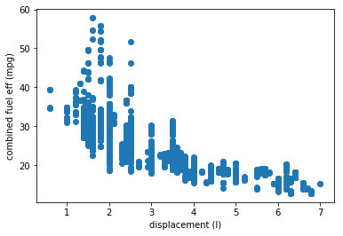

```python
plt.scatter(data=df,x='displ',y='comb')
plt.xlabel('displacement (l)')
plt.ylabel('combined fuel eff (mpg)');
```

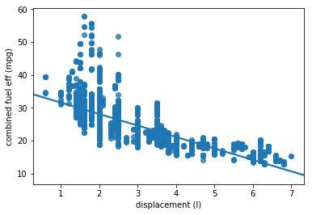

```python
# alternative method
sns.regplot(data=df,x='displ',y='comb')
plt.xlabel('displacement (l)')
plt.ylabel('combined fuel eff (mpg)');
```

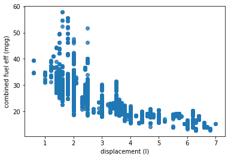

```python
# alternative method
sns.regplot(data=df,x='displ',y='comb',fit_reg = False)
plt.xlabel('displacement (l)')
plt.ylabel('combined fuel eff (mpg)');
```

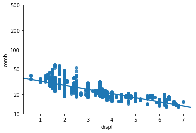

```python
def log_trans(x,inverse=False):
    if not inverse:
        return np.log10(x)
    else:
        return np.power(10,x)

sns.regplot(df.displ,df.comb.apply(log_trans))
tick_locs = [10,20,50,100,200,500]
plt.yticks(log_trans(tick_locs),tick_locs);
```

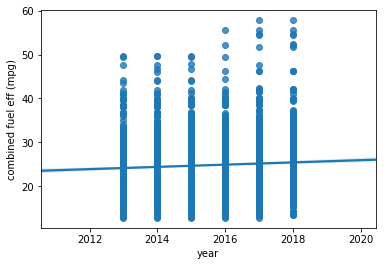

```python
sns.regplot(data=df,x='year',y='comb')
plt.xlabel('year')
plt.ylabel('combined fuel eff (mpg)');
```

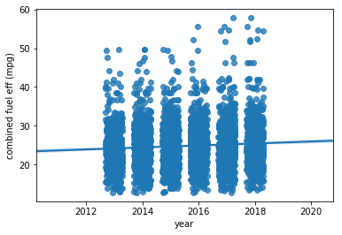

```python
# x_jitter works only with regplot and can't be used with matplotlib's scatter
sns.regplot(data=df,x='year',y='comb',x_jitter = 0.3)
plt.xlabel('year')
plt.ylabel('combined fuel eff (mpg)');
```

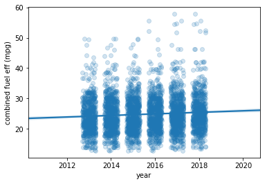

```python
# in matplotlib scatter we can direct add a parameter alpha with its value
sns.regplot(data=df,x='year',y='comb',x_jitter = 0.3, scatter_kws = {'alpha':1/5})
plt.xlabel('year')
plt.ylabel('combined fuel eff (mpg)');
```

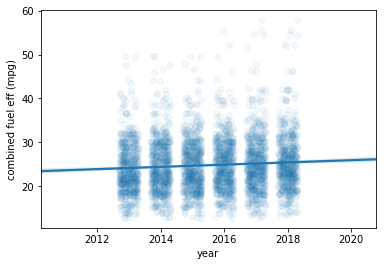

```python
sns.regplot(data=df,x='year',y='comb',x_jitter = 0.3, scatter_kws = {'alpha':1/20})
plt.xlabel('year')
plt.ylabel('combined fuel eff (mpg)');
```

## Heat maps : plt.hist2d( )

heat maps for quantitative variable vs quantitative variable:

- Good for discrete variable vs discrete variable
- Good alternative to transparency for a lot of data.
- Bin sizes are important

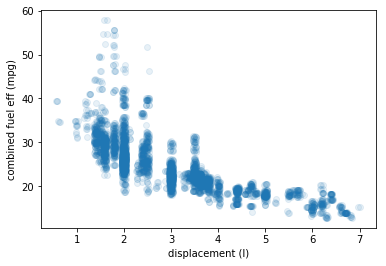

```python
sns.regplot(data = df, x = 'displ', y = 'comb', x_jitter = 0.04, scatter_kws = {'alpha':1/10}, fit_reg=False)
plt.xlabel('displacement (l)')
plt.ylabel('combined fuel eff (mpg)');
```

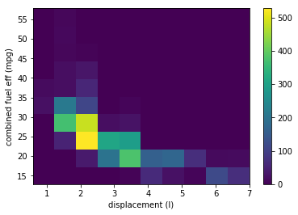

```python
plt.hist2d(data = df, x = 'displ', y = 'comb')
plt.colorbar()
plt.xlabel('displacement (l)')
plt.ylabel('combined fuel eff (mpg)');
```

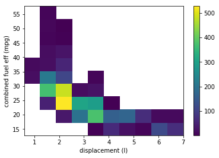

```python
plt.hist2d(data = df, x = 'displ', y = 'comb',cmin = 0.5)
plt.colorbar()
plt.xlabel('displacement (l)')
plt.ylabel('combined fuel eff (mpg)');
```

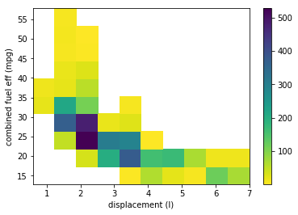

```python
plt.hist2d(data = df, x = 'displ', y = 'comb',cmin = 0.5, cmap = 'viridis_r')
plt.colorbar()
plt.xlabel('displacement (l)')
plt.ylabel('combined fuel eff (mpg)');
```

```python
df[['displ','comb']].describe()
```

|  | displ | comb |
| --- | --- | --- |
| count | 3929.000000 | 3929.000000 |
| mean | 2.950573 | 24.791339 |
| std | 1.305901 | 6.003246 |
| min | 0.600000 | 12.821700 |
| 25% | 2.000000 | 20.658100 |
| 50% | 2.500000 | 24.000000 |
| 75% | 3.600000 | 28.227100 |
| max | 7.000000 | 57.782400 |

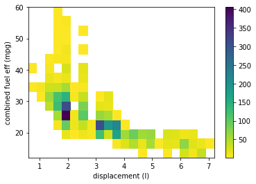

```python
bins_x = np.arange(0.6, 7+0.3, 0.3)
bins_y = np.arange(12, 58+3, 3)

plt.hist2d(data = df, x = 'displ', y = 'comb',cmin = 0.5, cmap = 'viridis_r', bins = [bins_x,bins_y])
plt.colorbar()
plt.xlabel('displacement (l)')
plt.ylabel('combined fuel eff (mpg)');
```

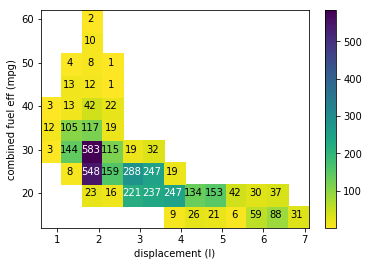

```python
bins_x = np.arange(0.6, 7+0.5, 0.5)
bins_y = np.arange(12, 58+5, 5)

h2d = plt.hist2d(data = df, x = 'displ', y = 'comb',cmin = 0.5, cmap = 'viridis_r', bins = [bins_x,bins_y])
plt.colorbar()
plt.xlabel('displacement (l)')
plt.ylabel('combined fuel eff (mpg)');

counts = h2d[0]

for i in range(counts.shape[0]):
    for j in range(counts.shape[1]):
        c = counts[i,j]
        if c>=220:
            plt.text(bins_x[i]+0.2,bins_y[j]+3,int(c),
                    ha='center',va='center',color='white')
        elif c>0:
            plt.text(bins_x[i]+0.2,bins_y[j]+3,int(c),
                    ha='center',va='center',color='black')
```

## Violin Plots: sns.violinplot( )

There are a few ways of plotting the relationship between one quantitative and one qualitative variable, that demonstrate the data at different levels of abstraction. The violin plot is on the lower level of abstraction. For each level of the categorical variable, a distribution of the values on the numeric variable is plotted. The distribution is plotted as a kernel density estimate, something like a smoothed histogram.

```python
df.VClass.unique()
```

```
array(['Subcompact Cars', 'Compact Cars', 'Midsize Cars', 'Large Cars',
       'Minicompact Cars'], dtype=object)
```

```python
sedan_classes = ['Minicompact Cars','Subcompact Cars', 'Compact Cars', 'Midsize Cars', 'Large Cars']
vclasses = pd.api.types.CategoricalDtype( ordered = True, categories = sedan_classes)
df['VClass'] = df['VClass'].astype(vclasses)
```

```python
df.dtypes
```

```
id              int64
make           object
model          object
year            int64
VClass       category
drive          object
trans          object
fuelType       object
cylinders       int64
displ         float64
pv2             int64
pv4             int64
city          float64
UCity         float64
highway       float64
UHighway      float64
comb          float64
co2             int64
feScore         int64
ghgScore        int64
dtype: object
```

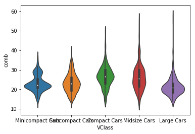

```python
sns.violinplot(data = df, x='VClass', y ='comb')
```

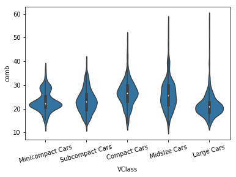

```python
base_color = sns.color_palette()[0]
sns.violinplot(data = df, x='VClass', y ='comb',color=base_color);
plt.xticks(rotation = 15);
```

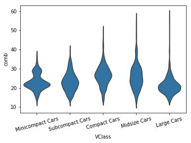

```python
base_color = sns.color_palette()[0]
sns.violinplot(data = df, x='VClass', y ='comb',color=base_color, inner = None);
plt.xticks(rotation = 15);
```

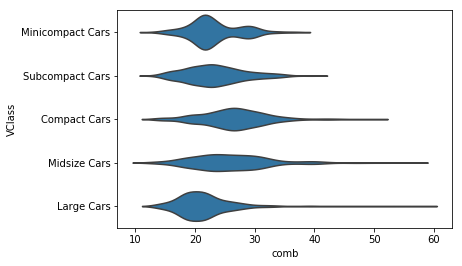

```python
base_color = sns.color_palette()[0]
sns.violinplot(data = df, y='VClass', x ='comb',color=base_color, inner = None);
```

## Box plots : sns.boxplot( )

A box plot is another way of showing the relationship between a numeric variable and a categorical variable. Compared to the violin plot, the box plot leans more on summarization of the data, primarily just reporting a set of descriptive statistics for the numeric values on each categorical level. A box plot can be created using seaborn's boxplot function.

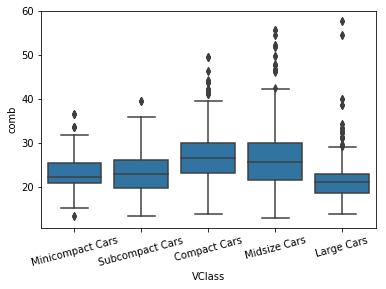

```python
base_color = sns.color_palette()[0]
sns.boxplot(data = df, x='VClass', y ='comb',color=base_color);
plt.xticks(rotation = 15);
```

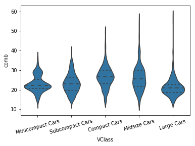

```python
base_color = sns.color_palette()[0]
sns.violinplot(data = df, x='VClass', y ='comb',color=base_color, inner = 'quartile');
plt.xticks(rotation = 15);
```

## Clustered Bar charts : sns.heatmap( ), sns.countplot( )

Used for visualizing qualitative variable vs qualitative variable

```python
df['trans_type'] = df['trans'].apply(lambda x: x.split()[0])
```

```python
ct_counts = df.groupby(['VClass','trans_type']).size()
ct_counts
```

```
VClass            trans_type
Minicompact Cars  Automatic     188
                  Manual        133
Subcompact Cars   Automatic     502
                  Manual        171
Compact Cars      Automatic     784
                  Manual        338
Midsize Cars      Automatic     989
                  Manual        199
Large Cars        Automatic     605
                  Manual         20
dtype: int64
```

```python
ct_counts = df.groupby(['VClass','trans_type']).size()
ct_counts.reset_index(name='count')
```

|  | VClass | trans_type | count |
| --- | --- | --- | --- |
| 0 | Minicompact Cars | Automatic | 188 |
| 1 | Minicompact Cars | Manual | 133 |
| 2 | Subcompact Cars | Automatic | 502 |
| 3 | Subcompact Cars | Manual | 171 |
| 4 | Compact Cars | Automatic | 784 |
| 5 | Compact Cars | Manual | 338 |
| 6 | Midsize Cars | Automatic | 989 |
| 7 | Midsize Cars | Manual | 199 |
| 8 | Large Cars | Automatic | 605 |
| 9 | Large Cars | Manual | 20 |

```python
ct_counts = df.groupby(['VClass','trans_type']).size()
ct_counts = ct_counts.reset_index(name='count')
ct_counts = ct_counts.pivot(index = 'VClass', columns='trans_type',values = 'count')
ct_counts
```

| trans_type VClass | Automatic | Manual |
| --- | --- | --- |
| Minicompact Cars | 188 | 133 |
| Subcompact Cars | 502 | 171 |
| Compact Cars | 784 | 338 |
| Midsize Cars | 989 | 199 |
| Large Cars | 605 | 20 |

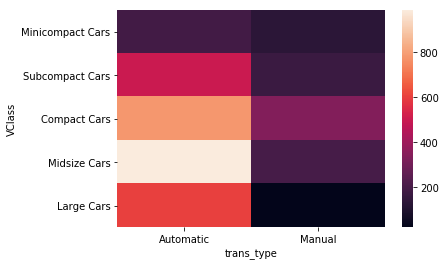

```python
sns.heatmap(ct_counts);
```

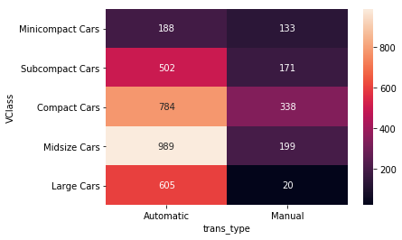

```python
sns.heatmap(ct_counts , annot = True , fmt = 'd');
```

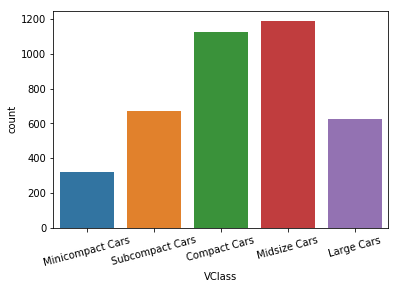

```python
sns.countplot(data = df, x='VClass')
plt.xticks(rotation=15);
```

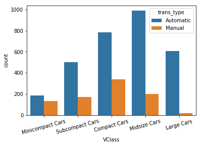

```python
sns.countplot(data = df, x='VClass', hue = 'trans_type')
plt.xticks(rotation=15);
```

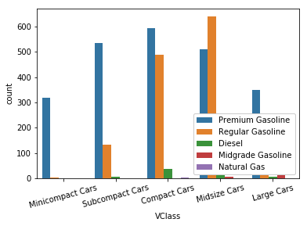

```python
ax = sns.countplot(data = df, x='VClass',hue='fuelType')
ax.legend(loc = 4, framealpha =1 )
plt.xticks(rotation = 15);
```

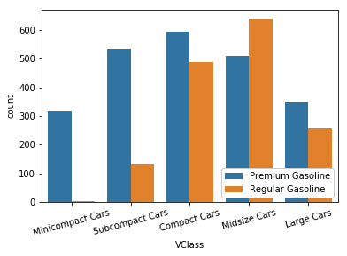

```python
fuel_econ_sub = df.loc[df['fuelType'].isin(['Premium Gasoline', 'Regular Gasoline'])]

ax = sns.countplot(data = fuel_econ_sub, x='VClass',hue='fuelType')
ax.legend(loc = 4, framealpha =1 )
plt.xticks(rotation = 15);
```

## Faceting

making multiple copies of the same type of plot visualized on different subsets of the data is called faceting.

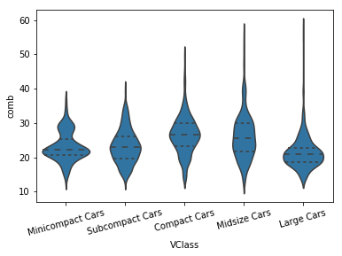

```python
base_color = sns.color_palette()[0]
sns.violinplot(data = df, x='VClass', y ='comb',color=base_color, inner = 'quartile');
plt.xticks(rotation = 15);
```

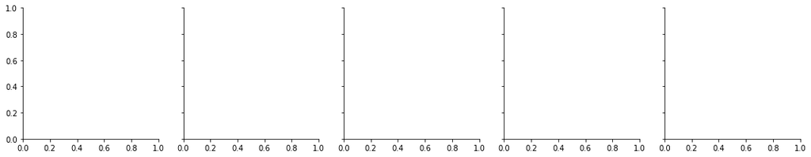

```python
g = sns.FacetGrid(data = df, col = 'VClass');
```

each axes is for different levels of VClass

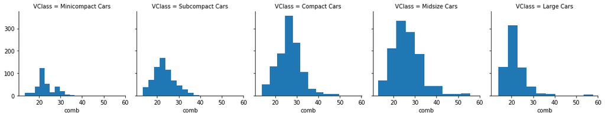

```python
g = sns.FacetGrid(data = df, col = 'VClass');
g.map(plt.hist,'comb');
```

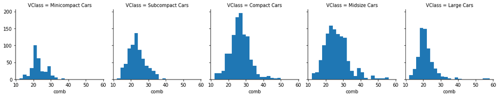

```python
bins = np.arange(12,58+2,2)
g = sns.FacetGrid(data = df, col = 'VClass');
g.map(plt.hist,'comb',bins = bins);
```

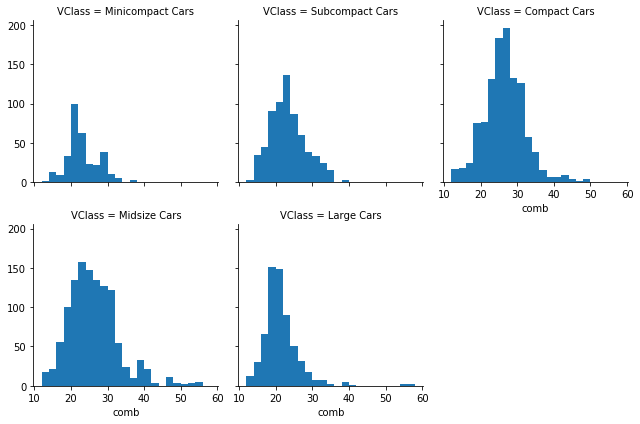

```python
bins = np.arange(12,58+2,2)
g = sns.FacetGrid(data = df, col = 'VClass', col_wrap = 3);
g.map(plt.hist,'comb',bins = bins);
```

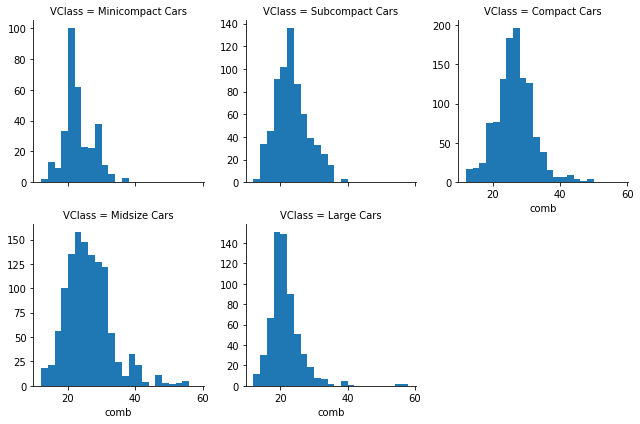

```python
bins = np.arange(12,58+2,2)
g = sns.FacetGrid(data = df, col = 'VClass', col_wrap = 3, sharey = False);
g.map(plt.hist,'comb',bins = bins);
```

## Adaption of Univariate plots

### 1. Adaptation of Bar plots for Box plots : sns.barplot( ) , sns.pointplot( )

Additional option we have for plotting one quantitative variable against one qualitative variable is the adaptation of bar charts. insted of showing counts on vertical axis, we can show the mean of the second variable.

we have to use sns.barplot() instead of sns.countplot()

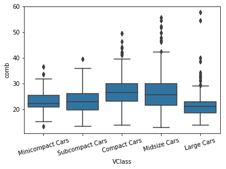

```python
base_color = sns.color_palette()[0]
sns.boxplot(data = df, x='VClass', y ='comb',color=base_color);
plt.xticks(rotation = 15);
```

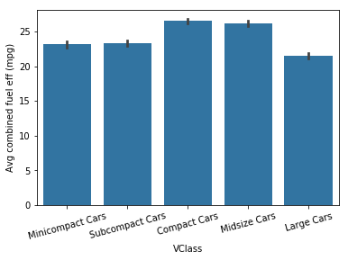

```python
base_color = sns.color_palette()[0]
sns.barplot(data = df, x='VClass', y ='comb',color=base_color);
plt.xticks(rotation = 15);
plt.ylabel('Avg combined fuel eff (mpg)');
```

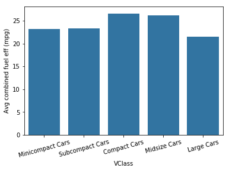

```python
base_color = sns.color_palette()[0]
sns.barplot(data = df, x='VClass', y ='comb',color=base_color, errwidth =0);
plt.xticks(rotation = 15);
plt.ylabel('Avg combined fuel eff (mpg)');
```

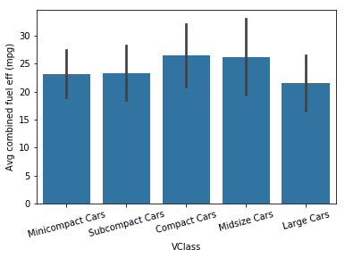

```python
# to plot standard deviation
base_color = sns.color_palette()[0]
sns.barplot(data = df, x='VClass', y ='comb',color=base_color, ci = 'sd');
plt.xticks(rotation = 15);
plt.ylabel('Avg combined fuel eff (mpg)');
```

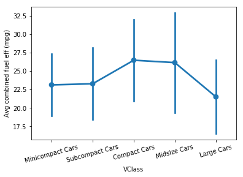

```python
base_color = sns.color_palette()[0]
sns.pointplot(data = df, x='VClass', y ='comb',color=base_color, ci = 'sd');
plt.xticks(rotation = 15);
plt.ylabel('Avg combined fuel eff (mpg)');
```

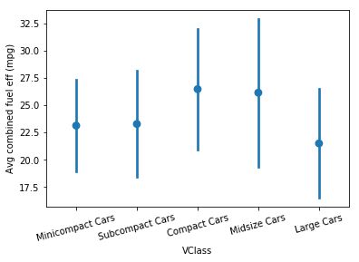

```python
base_color = sns.color_palette()[0]
sns.pointplot(data = df, x='VClass', y ='comb', ci = 'sd', linestyles = "");
plt.xticks(rotation = 15);
plt.ylabel('Avg combined fuel eff (mpg)');
```

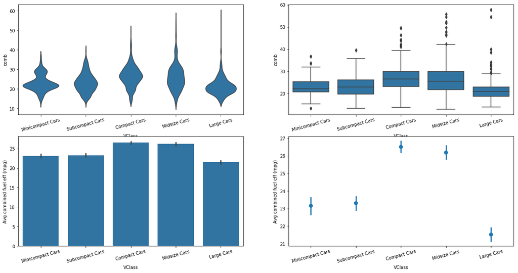

```python
plt.figure(figsize = [20,10])

plt.subplot(2,2,1)
sns.violinplot(data = df, x='VClass', y ='comb',color=base_color, inner = None);
plt.xticks(rotation = 15);

plt.subplot(2,2,2)
sns.boxplot(data = df, x='VClass', y ='comb',color=base_color);
plt.xticks(rotation = 15);

plt.subplot(2,2,3)
sns.barplot(data = df, x='VClass', y ='comb',color=base_color);
plt.xticks(rotation = 15);
plt.ylabel('Avg combined fuel eff (mpg)');

plt.subplot(2,2,4)
sns.pointplot(data = df, x='VClass', y ='comb', linestyles = "");
plt.xticks(rotation = 15);
plt.ylabel('Avg combined fuel eff (mpg)');
```

## Line plots : plt.errorbar( )

In a line plot, we plot the relationship between two quantitative variables, one on each axis using a line. The Y value on the line at any given x value, reports the average value taken by the y-axis variable. This is like a histogram with variaable-average instead of count on y-axis, and point positions instead of bar heights.

The use of lines emphasize two things over bars:

- emphasize relative change
- emphasize tends across x values

The line emphasizes the connections between values on the x axis. That means that it is inappropriate to use a line plot if we have a nominal variable on x axis. Frequently we will see bivariate plots against a time-based variable as a line-plot. you see this in economic data like stock or currency charts, plotting the enitities values across a period of time.

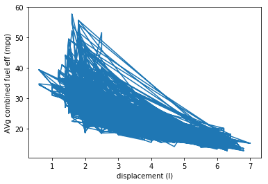

```python
plt.errorbar(data=df,x='displ',y='comb')
plt.xlabel('displacement (l)')
plt.ylabel('AVg combined fuel eff (mpg)');
```

```python
bins_e = np.arange(0.6,7+0.2,0.2)
bins_c = bins_e[:-1] + 0.1

print(bins_e)
print(bins_c)
```

```
[0.6 0.8 1.  1.2 1.4 1.6 1.8 2.  2.2 2.4 2.6 2.8 3.  3.2 3.4 3.6 3.8 4.
 4.2 4.4 4.6 4.8 5.  5.2 5.4 5.6 5.8 6.  6.2 6.4 6.6 6.8 7. ]
[0.7 0.9 1.1 1.3 1.5 1.7 1.9 2.1 2.3 2.5 2.7 2.9 3.1 3.3 3.5 3.7 3.9 4.1
 4.3 4.5 4.7 4.9 5.1 5.3 5.5 5.7 5.9 6.1 6.3 6.5 6.7 6.9]
```

```python
df.head()
```

|  | id | make | model | year | VClass | drive | trans | fuelType | cylinders | displ | ... | pv4 | city | UCity | highway | UHighway | comb | co2 | feScore | ghgScore | trans_type |
| --- | --- | --- | --- | --- | --- | --- | --- | --- | --- | --- | --- | --- | --- | --- | --- | --- | --- | --- | --- | --- | --- |
| 0 | 32204 | Nissan | GT-R | 2013 | Subcompact Cars | All-Wheel Drive | Automatic (AM6) | Premium Gasoline | 6 | 3.8 | ... | 0 | 16.4596 | 20.2988 | 22.5568 | 30.1798 | 18.7389 | 471 | 4 | 4 | Automatic |
| 1 | 32205 | Volkswagen | CC | 2013 | Compact Cars | Front-Wheel Drive | Automatic (AM-S6) | Premium Gasoline | 4 | 2.0 | ... | 0 | 21.8706 | 26.9770 | 31.0367 | 42.4936 | 25.2227 | 349 | 6 | 6 | Automatic |
| 2 | 32206 | Volkswagen | CC | 2013 | Compact Cars | Front-Wheel Drive | Automatic (S6) | Premium Gasoline | 6 | 3.6 | ... | 0 | 17.4935 | 21.2000 | 26.5716 | 35.1000 | 20.6716 | 429 | 5 | 5 | Automatic |
| 3 | 32207 | Volkswagen | CC 4motion | 2013 | Compact Cars | All-Wheel Drive | Automatic (S6) | Premium Gasoline | 6 | 3.6 | ... | 0 | 16.9415 | 20.5000 | 25.2190 | 33.5000 | 19.8774 | 446 | 5 | 5 | Automatic |
| 4 | 32208 | Chevrolet | Malibu eAssist | 2013 | Midsize Cars | Front-Wheel Drive | Automatic (S6) | Regular Gasoline | 4 | 2.4 | ... | 95 | 24.7726 | 31.9796 | 35.5340 | 51.8816 | 28.6813 | 310 | 8 | 8 | Automatic |

5 rows × 21 columns

```python
displ_binned = pd.cut(df.displ,bins_e,include_lowest=True)
displ_binned
```

```
0       (3.6, 3.8]
1       (1.8, 2.0]
2       (3.4, 3.6]
3       (3.4, 3.6]
4       (2.2, 2.4]
           ...
3924    (1.6, 1.8]
3925    (1.8, 2.0]
3926    (1.8, 2.0]
3927    (3.2, 3.4]
3928    (3.2, 3.4]
Name: displ, Length: 3929, dtype: category
Categories (32, interval[float64]): [(0.599, 0.8] < (0.8, 1.0] < (1.0, 1.2] < (1.2, 1.4] ... (6.2, 6.4] < (6.4, 6.6] < (6.6, 6.8] < (6.8, 7.0]]
```

```python
df.comb.groupby(displ_binned).mean()
```

```
displ
(0.599, 0.8]    37.057583
(0.8, 1.0]      33.469158
(1.0, 1.2]      35.838600
(1.2, 1.4]      31.964468
(1.4, 1.6]      30.489490
(1.6, 1.8]      31.996801
(1.8, 2.0]      27.534614
(2.0, 2.2]      31.790900
(2.2, 2.4]      26.888429
(2.4, 2.6]      28.589656
(2.6, 2.8]      20.227183
(2.8, 3.0]      22.464063
(3.0, 3.2]      22.638350
(3.2, 3.4]      21.962225
(3.4, 3.6]      22.602561
(3.6, 3.8]      20.616143
(3.8, 4.0]      18.977208
(4.0, 4.2]      18.320850
(4.2, 4.4]      18.160620
(4.4, 4.6]      18.668650
(4.6, 4.8]      18.661085
(4.8, 5.0]      18.054693
(5.0, 5.2]      16.481675
(5.2, 5.4]            NaN
(5.4, 5.6]      17.972043
(5.6, 5.8]      18.455833
(5.8, 6.0]      15.161788
(6.0, 6.2]      16.428960
(6.2, 6.4]      16.452696
(6.4, 6.6]      14.890232
(6.6, 6.8]      13.716614
(6.8, 7.0]      15.256400
Name: comb, dtype: float64
```

```python
bins_e = np.arange(0.6,7+0.2,0.2)
bins_c = bins_e[:-1] + 0.1

displ_binned = pd.cut(df['displ'], bins_e, include_lowest=True)
comb_mean = df['comb'].groupby(displ_binned).mean()
```

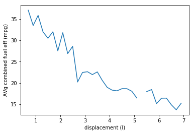

```python
plt.errorbar(x = bins_c , y = comb_mean);
plt.xlabel('displacement (l)')
plt.ylabel('AVg combined fuel eff (mpg)');
```

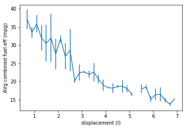

```python
comb_sd = df['comb'].groupby(displ_binned).std()

plt.errorbar(x = bins_c , y = comb_mean, yerr = comb_sd);
plt.xlabel('displacement (l)')
plt.ylabel('AVg combined fuel eff (mpg)');
```

Plot the distribution of combined fuel mileage (column 'comb', in miles per gallon) by manufacturer (column 'make'), for all manufacturers with at least eighty cars in the dataset. Consider which manufacturer order will convey the most information when constructing your final plot. Hint: Completing this exercise will take multiple steps! Add additional code cells as needed in order to achieve the goal.`

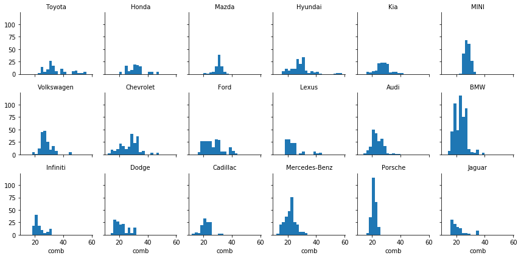

```python
    # data setup
fuel_econ = pd.read_csv('fuel_econ.csv')

THRESHOLD = 80
make_frequency = fuel_econ['make'].value_counts()
idx = np.sum(make_frequency > THRESHOLD)

most_makes = make_frequency.index[:idx]
fuel_econ_sub = fuel_econ.loc[fuel_econ['make'].isin(most_makes)]

make_means = fuel_econ_sub.groupby('make').mean()
comb_order = make_means.sort_values('comb', ascending = False).index

    # plotting
g = sns.FacetGrid(data = fuel_econ_sub, col = 'make', col_wrap = 6, size = 2,
                     col_order = comb_order)
    # try sb.distplot instead of plt.hist to see the plot in terms of density!
g.map(plt.hist, 'comb', bins = np.arange(12, fuel_econ_sub['comb'].max()+2, 2))
g.set_titles('{col_name}')
```

Continuing on from the previous task, plot the mean fuel efficiency for each manufacturer with at least 80 cars in the dataset.

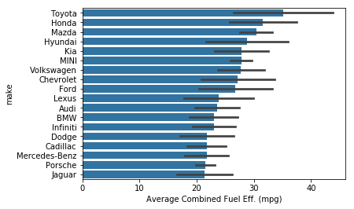

```python
sns.barplot(data = fuel_econ_sub, x = 'comb', y = 'make',
               color = base_color, order = comb_order, ci = 'sd')
plt.xlabel('Average Combined Fuel Eff. (mpg)')
```

## Swarm Plots : sns.swarmplot( )

we saw many ways of depicting the relationship between a numeric variable and a categorical variable. Violin plots depicted distributions as density curves, while box plots took a more summary approach, plotting the quantiles as boxes with whiskers. Another alternative to these plots is the swarm plot. Similar to a scatterplot, each data point is plotted with position according to its value on the two variables being plotted. Instead of randomly jittering points as in a normal scatterplot, points are placed as close to their actual value as possible without allowing any overlap. A swarm plot can be created in seaborn using the swarmplot function, similar to how you would a call violinplot or boxplot.

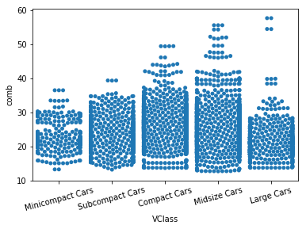

```python
sns.swarmplot(data = df, x='VClass', y ='comb',color=base_color);
plt.xticks(rotation = 15);
```

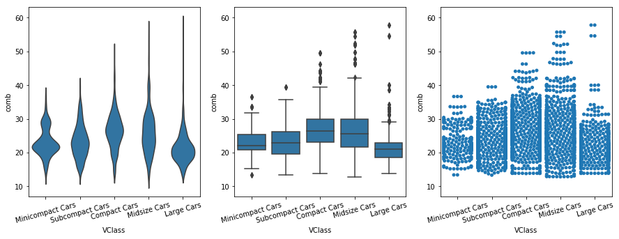

```python
plt.figure(figsize = [15,5])
base_color = sns.color_palette()[0]

plt.subplot(1,3,1)
ax1 = sns.violinplot(data = df, x='VClass', y ='comb',color=base_color, inner = None);
plt.xticks(rotation = 15);

plt.subplot(1,3,2)
sns.boxplot(data = df, x='VClass', y ='comb',color=base_color);
plt.xticks(rotation = 15);
plt.ylim(ax1.get_ylim())

plt.subplot(1,3,3)
sns.swarmplot(data = df, x='VClass', y ='comb',color=base_color);
plt.xticks(rotation = 15);
plt.ylim(ax1.get_ylim());
```

Looking at the plots side by side, you can see relative pros and cons of the swarm plot. Unlike the violin plot and box plot, every point is plotted, so we can now compare the frequency of each group in the same plot. While there is some distortion due to location jitter, we also have a more concrete picture of where the points actually lie, removing the long tails that can be present in violin plots.

However, it is only reasonable to use a swarm plot if we have a small or moderate amount of data. If we have too many points, then the restrictions against overlap will cause too much distortion or require a lot of space to plot the data comfortably. In addition, having too many points can actually be a distraction, making it harder to see the key signals in the visualization. Use your findings from univariate visualizations to inform which bivariate visualizations will be best, or simply experiment with different plot types to see what is most informative.

## Rug plot : sns.rugplot( )

We might encounter, or be interested in, marginal distributions that are plotted alongside bivariate plots such as scatterplots. A marginal distribution is simply the univariate distribution of a variable, ignoring the values of any other variable. For quantitative data, histograms or density curves are fine choices for marginal plot, but you might also see the rug plot employed. In a rug plot, all of the data points are plotted on a single axis, one tick mark or line for each one. Compared to a marginal histogram, the rug plot suffers somewhat in terms of readability of the distribution, but it is more compact in its representation of the data.`

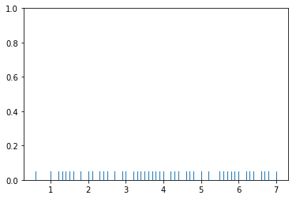

```python
sns.rugplot(df['displ']);
```

Seaborn's JointGrid class enables this plotting of bivariate relationship with marginal univariate plots for numeric data. The plot_joint method specifies a plotting function for the main, joint plot for the two variables, while the plot_marginals method specifies the plotting function for the two marginal plots. Here, we make use of seaborn's rugplot function.

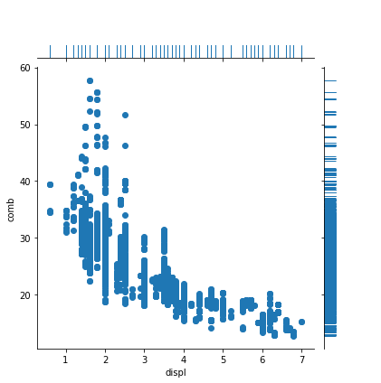

```python
g = sns.JointGrid(data = df, x='displ',y='comb')
g.plot_joint(plt.scatter)
g.plot_marginals(sns.rugplot, height = 0.25)
```

The rug plot is fine here since the data isn't particularly numerous or overly dense for displ nut it is not fine for comb as it is overly dense. In other circumstances, a histogram or density curve will be more appropriate. You probably won't consider the rug plot as a primary plot choice, but it can be a good supporter plot in certain circumstances.

## Strip Plot : sns.stripplot( )

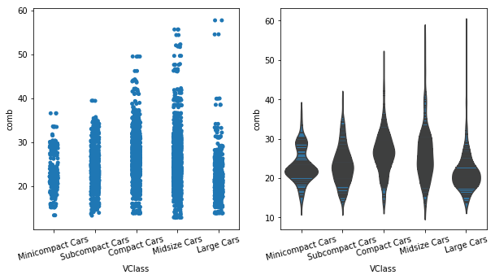

```python
plt.figure(figsize=[10,5])
plt.subplot(1,2,1)
ax1 = sns.stripplot(data = df, x='VClass',y='comb',color = base_color)
plt.xticks(rotation=15)

plt.subplot(1,2,2)
sns.violinplot(data = df, x='VClass',y='comb',color = base_color, inner='stick')
plt.xticks(rotation=15);
```

# Data Visualization : Multivariate

```python
df = pd.read_csv('fuel_econ.csv')

sedan_classes = ['Minicompact Cars','Subcompact Cars', 'Compact Cars', 'Midsize Cars', 'Large Cars']

vclasses = pd.api.types.CategoricalDtype( ordered = True, categories = sedan_classes)

df['VClass'] = df['VClass'].astype(vclasses)

df['trans_type'] = df['trans'].apply(lambda x: x.split()[0])
```

```python
df.head()
```

|  | id | make | model | year | VClass | drive | trans | fuelType | cylinders | displ | ... | pv4 | city | UCity | highway | UHighway | comb | co2 | feScore | ghgScore | trans_type |
| --- | --- | --- | --- | --- | --- | --- | --- | --- | --- | --- | --- | --- | --- | --- | --- | --- | --- | --- | --- | --- | --- |
| 0 | 32204 | Nissan | GT-R | 2013 | Subcompact Cars | All-Wheel Drive | Automatic (AM6) | Premium Gasoline | 6 | 3.8 | ... | 0 | 16.4596 | 20.2988 | 22.5568 | 30.1798 | 18.7389 | 471 | 4 | 4 | Automatic |
| 1 | 32205 | Volkswagen | CC | 2013 | Compact Cars | Front-Wheel Drive | Automatic (AM-S6) | Premium Gasoline | 4 | 2.0 | ... | 0 | 21.8706 | 26.9770 | 31.0367 | 42.4936 | 25.2227 | 349 | 6 | 6 | Automatic |
| 2 | 32206 | Volkswagen | CC | 2013 | Compact Cars | Front-Wheel Drive | Automatic (S6) | Premium Gasoline | 6 | 3.6 | ... | 0 | 17.4935 | 21.2000 | 26.5716 | 35.1000 | 20.6716 | 429 | 5 | 5 | Automatic |
| 3 | 32207 | Volkswagen | CC 4motion | 2013 | Compact Cars | All-Wheel Drive | Automatic (S6) | Premium Gasoline | 6 | 3.6 | ... | 0 | 16.9415 | 20.5000 | 25.2190 | 33.5000 | 19.8774 | 446 | 5 | 5 | Automatic |
| 4 | 32208 | Chevrolet | Malibu eAssist | 2013 | Midsize Cars | Front-Wheel Drive | Automatic (S6) | Regular Gasoline | 4 | 2.4 | ... | 95 | 24.7726 | 31.9796 | 35.5340 | 51.8816 | 28.6813 | 310 | 8 | 8 | Automatic |

5 rows × 21 columns

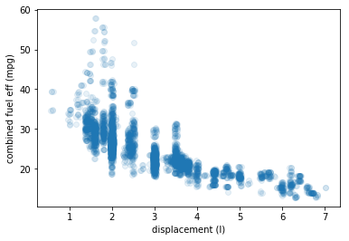

```python
sns.regplot(data = df, x = 'displ', y = 'comb', x_jitter = 0.04, scatter_kws = {'alpha':1/10}, fit_reg=False)
plt.xlabel('displacement (l)')
plt.ylabel('combined fuel eff (mpg)');
```

## Non positional Encodings for Third variables

There are four major cases to consider when we want to plot three variables together:

- three numeric variables
- two numeric variables and one categorical variable
- one numeric variable and two categorical variables
- three categorical variables

If we have at least two numeric variables, as in the first two cases, one common method for depicting the data is by using a scatterplot to encode two of the numeric variables, then using a non-positional encoding on the points to convey the value on the third variable, whether numeric or categorical. (You will see additional techniques later in the lesson that can also be applied to the other two cases, i.e. where we have at least two categorical variables.)

Three main non-positional encodings stand out: shape, size, and color. For Matplotlib and Seaborn, color is the easiest of these three encodings to apply for a third variable. Color can be used to encode both qualitative and quantitative data, with different types of color palettes used for different use cases.

```python
np.random.seed(2018)
df_subset = df.sample(200,replace = False)
```

```python
df_subset.shape
```

```
(200, 21)
```

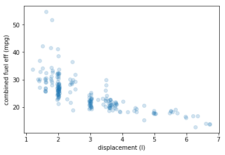

```python
sns.regplot(data = df_subset, x = 'displ', y = 'comb', x_jitter = 0.04, scatter_kws = {'alpha':1/5}, fit_reg=False)
plt.xlabel('displacement (l)')
plt.ylabel('combined fuel eff (mpg)');
```

**Are there differences between cars with automatic transmission and manual transmission in terms of fuel efficieny and engine size?**

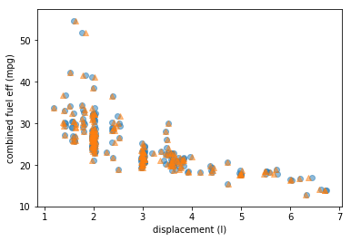

```python
# since transmission type is categorical, shape is a good encoding to use

markers = [['Automatic','o'],['Manual','^']]
for ttype,marker in markers:
    plot_data = df_subset.loc[df_subset.trans_type == ttype ]
    sns.regplot(data = df_subset, x = 'displ', y = 'comb', x_jitter = 0.04,
                marker = marker, fit_reg=False, scatter_kws = {'alpha':0.5})
plt.xlabel('displacement (l)')
plt.ylabel('combined fuel eff (mpg)');
```

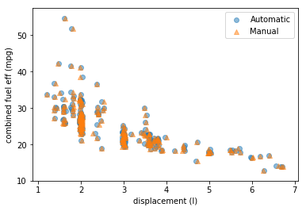

```python
# since transmission type is categorical, shape is a good encoding to use

markers = [['Automatic','o'],['Manual','^']]
for ttype,marker in markers:
    plot_data = df_subset.loc[df_subset.trans_type == ttype ]
    sns.regplot(data = df_subset, x = 'displ', y = 'comb', x_jitter = 0.04,
                marker = marker, fit_reg=False, scatter_kws = {'alpha':0.5})
plt.xlabel('displacement (l)')
plt.ylabel('combined fuel eff (mpg)');
plt.legend(['Automatic','Manual'])
```

**Instead of trans_type , add co2 as third variable for fuel efficiency and engine size scatter plot?**

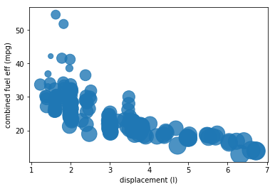

```python
# as the third variable is numeric, size is a good encoding to use

sns.regplot(data = df_subset, x = 'displ', y = 'comb', x_jitter = 0.04,
            scatter_kws = {'s':df_subset['co2']}, fit_reg=False)
plt.xlabel('displacement (l)')
plt.ylabel('combined fuel eff (mpg)');
```

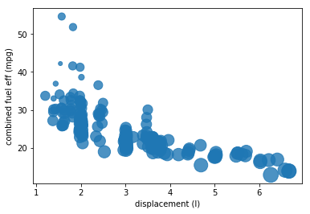

```python
# as the third variable is numeric, size is a good encoding to use

sns.regplot(data = df_subset, x = 'displ', y = 'comb', x_jitter = 0.04,
            scatter_kws = {'s':df_subset['co2']/2}, fit_reg=False)
plt.xlabel('displacement (l)')
plt.ylabel('combined fuel eff (mpg)');
```

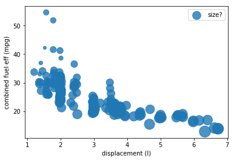

```python
# as the third variable is numeric, size is a good encoding to use

sns.regplot(data = df_subset, x = 'displ', y = 'comb', x_jitter = 0.04,
            scatter_kws = {'s':df_subset['co2']/2}, fit_reg=False)
plt.xlabel('displacement (l)')
plt.ylabel('combined fuel eff (mpg)');
plt.legend(['size?'])
```

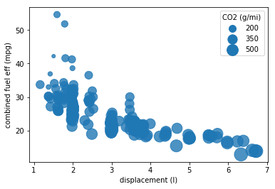

```python
# as the third variable is numeric, size is a good encoding to use

sns.regplot(data = df_subset, x = 'displ', y = 'comb', x_jitter = 0.04,
            scatter_kws = {'s':df_subset['co2']/2}, fit_reg=False)
plt.xlabel('displacement (l)')
plt.ylabel('combined fuel eff (mpg)');

sizes = [200,350,500]
legends = []
for s in sizes:
    legends.append(plt.scatter([],[],s = s/2,color=base_color))

plt.legend(legends,sizes,title = 'CO2 (g/mi)')
```

It might seem plausible to combine both size and shape encodings into the same plot, to depict the trend in four variables at once. Technically, this may be true, but there are some cautions to be taken with this approach. One surface issue is that the code to depict the plot and a reasonable legend gets complicated. A more important issue is that point areas won't all be the same even with the same value, depending on the shape of the marker:

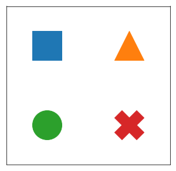

```python
plt.figure(figsize = [5,5])

common_size = 2500
plt.scatter([0],[1], marker = 's', s = common_size)
plt.scatter([1],[1], marker = '^', s = common_size)
plt.scatter([0],[0], marker = 'o', s = common_size)
plt.scatter([1],[0], marker = 'X', s = common_size)

# a little bit of aesthetic cleaning
plt.xlim(-0.5,1.5)
plt.xticks([])
plt.ylim(-0.5,1.5)
plt.yticks([]);
```